# Prasanna Velisetti

> **White Wine Quality**: The dataset contains physio-chemical properties of 4898 different samples of Portuguese “Vinho Verde” wine. The value for quality of wine is based on sensory data (median of at least 3 evaluations made by wine experts).The dataset will be used to assess the important physio-chemical properties that determines the quality of wine.There are no missig values in the dataset.

# Univariate Plots Section

```
## 'data.frame':    4898 obs. of  12 variables:
##  $ fixed.acidity       : num  7 6.3 8.1 7.2 7.2 8.1 6.2 7 6.3 8.1 ...
##  $ volatile.acidity    : num  0.27 0.3 0.28 0.23 0.23 0.28 0.32 0.27 0.3 0.22 ...
##  $ citric.acid         : num  0.36 0.34 0.4 0.32 0.32 0.4 0.16 0.36 0.34 0.43 ...
##  $ residual.sugar      : num  20.7 1.6 6.9 8.5 8.5 6.9 7 20.7 1.6 1.5 ...
##  $ chlorides           : num  0.045 0.049 0.05 0.058 0.058 0.05 0.045 0.045 0.049 0.044 ...
##  $ free.sulfur.dioxide : num  45 14 30 47 47 30 30 45 14 28 ...
##  $ total.sulfur.dioxide: num  170 132 97 186 186 97 136 170 132 129 ...
##  $ density             : num  1.001 0.994 0.995 0.996 0.996 ...
##  $ pH                  : num  3 3.3 3.26 3.19 3.19 3.26 3.18 3 3.3 3.22 ...
##  $ sulphates           : num  0.45 0.49 0.44 0.4 0.4 0.44 0.47 0.45 0.49 0.45 ...
##  $ alcohol             : num  8.8 9.5 10.1 9.9 9.9 10.1 9.6 8.8 9.5 11 ...
##  $ quality             : Ord.factor w/ 5 levels "Very Low"<"Low"<..: 3 3 3 3 3 3 3 3 3 3 ...
```

```
##  fixed.acidity    volatile.acidity  citric.acid     residual.sugar
##  Min.   : 3.800   Min.   :0.0800   Min.   :0.0000   Min.   : 0.600
##  1st Qu.: 6.300   1st Qu.:0.2100   1st Qu.:0.2700   1st Qu.: 1.700
##  Median : 6.800   Median :0.2600   Median :0.3200   Median : 5.200
##  Mean   : 6.855   Mean   :0.2782   Mean   :0.3342   Mean   : 6.391
##  3rd Qu.: 7.300   3rd Qu.:0.3200   3rd Qu.:0.3900   3rd Qu.: 9.900
##  Max.   :14.200   Max.   :1.1000   Max.   :1.6600   Max.   :65.800
##    chlorides       free.sulfur.dioxide total.sulfur.dioxide
##  Min.   :0.00900   Min.   :  2.00      Min.   :  9.0
##  1st Qu.:0.03600   1st Qu.: 23.00      1st Qu.:108.0
##  Median :0.04300   Median : 34.00      Median :134.0
##  Mean   :0.04577   Mean   : 35.31      Mean   :138.4
##  3rd Qu.:0.05000   3rd Qu.: 46.00      3rd Qu.:167.0
##  Max.   :0.34600   Max.   :289.00      Max.   :440.0
##     density             pH          sulphates         alcohol
##  Min.   :0.9871   Min.   :2.720   Min.   :0.2200   Min.   : 8.00
##  1st Qu.:0.9917   1st Qu.:3.090   1st Qu.:0.4100   1st Qu.: 9.50
##  Median :0.9937   Median :3.180   Median :0.4700   Median :10.40
##  Mean   :0.9940   Mean   :3.188   Mean   :0.4898   Mean   :10.51
##  3rd Qu.:0.9961   3rd Qu.:3.280   3rd Qu.:0.5500   3rd Qu.:11.40
##  Max.   :1.0390   Max.   :3.820   Max.   :1.0800   Max.   :14.20
##       quality
##  Very Low :   0
##  Low      : 183
##  Normal   :3655
##  High     :1055
##  Very High:   5
##
```

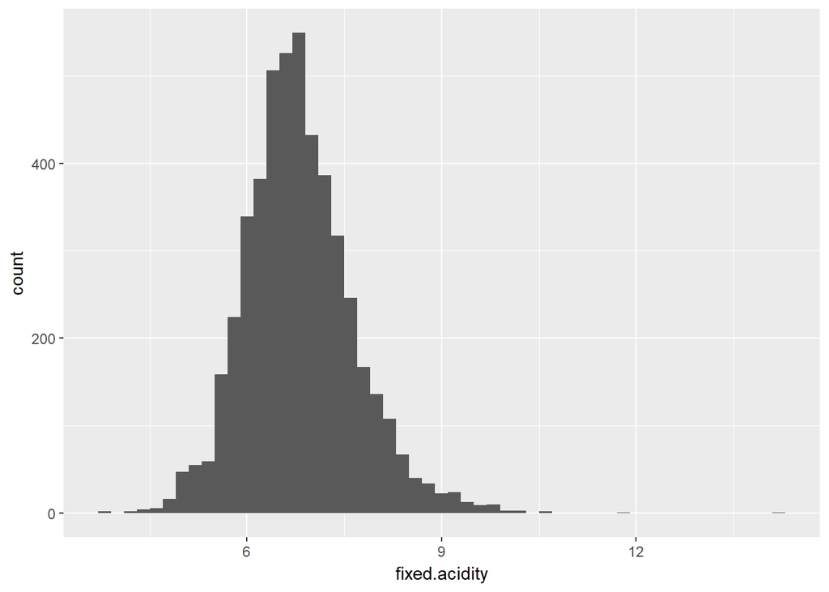

```
##    Min. 1st Qu.  Median    Mean 3rd Qu.    Max.
##   3.800   6.300   6.800   6.855   7.300  14.200
```

Fixed acidity distribution appears to be normal with a mean & median around 6.8 (g/dm^3).

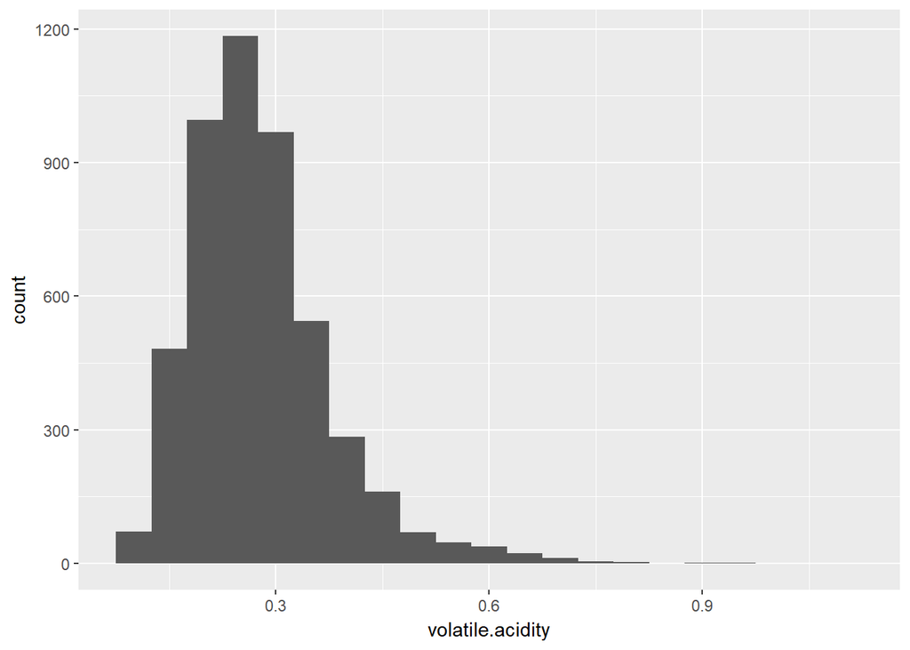

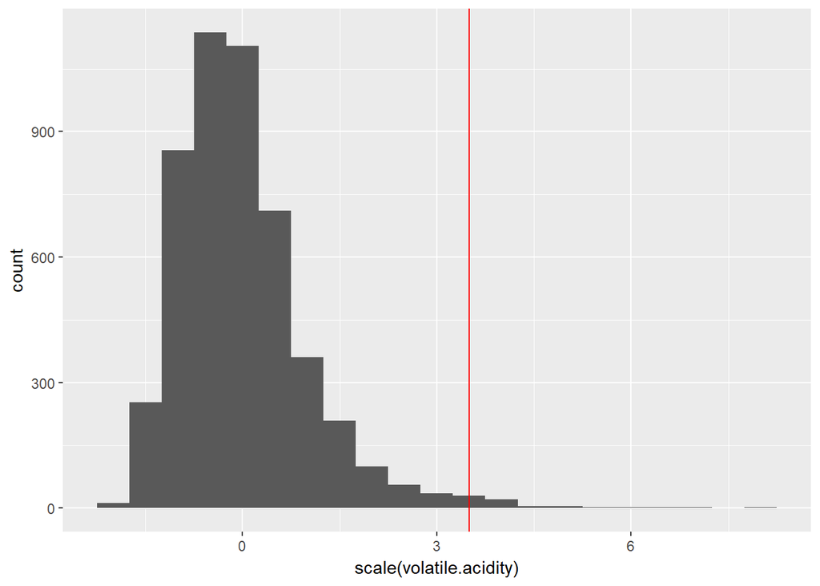

```
##    Min. 1st Qu.  Median    Mean 3rd Qu.    Max.
##  0.0800  0.2100  0.2600  0.2782  0.3200  1.1000
```

It can be seen that the distribution slightly right skewed. I wonder what happens if we combine both fixed acidity and volatile acidity as in terms of wine tasting, they both may not be distinguished.

Volatile acidity is standardized/scaled in the second graph to see if there are any outliers (>3.5)

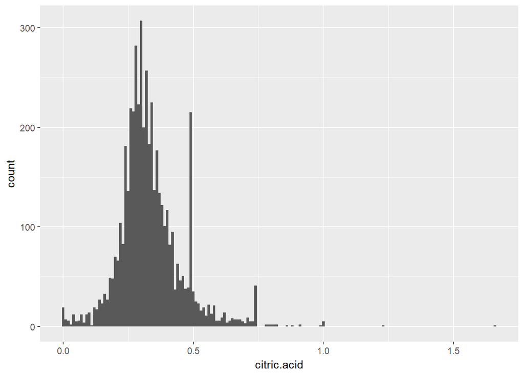

```
##    Min. 1st Qu.  Median    Mean 3rd Qu.    Max.
##  0.0000  0.2700  0.3200  0.3342  0.3900  1.6600
```

There is a sudden peak in the citric acid concentration around 0.5 (g / dm^3).

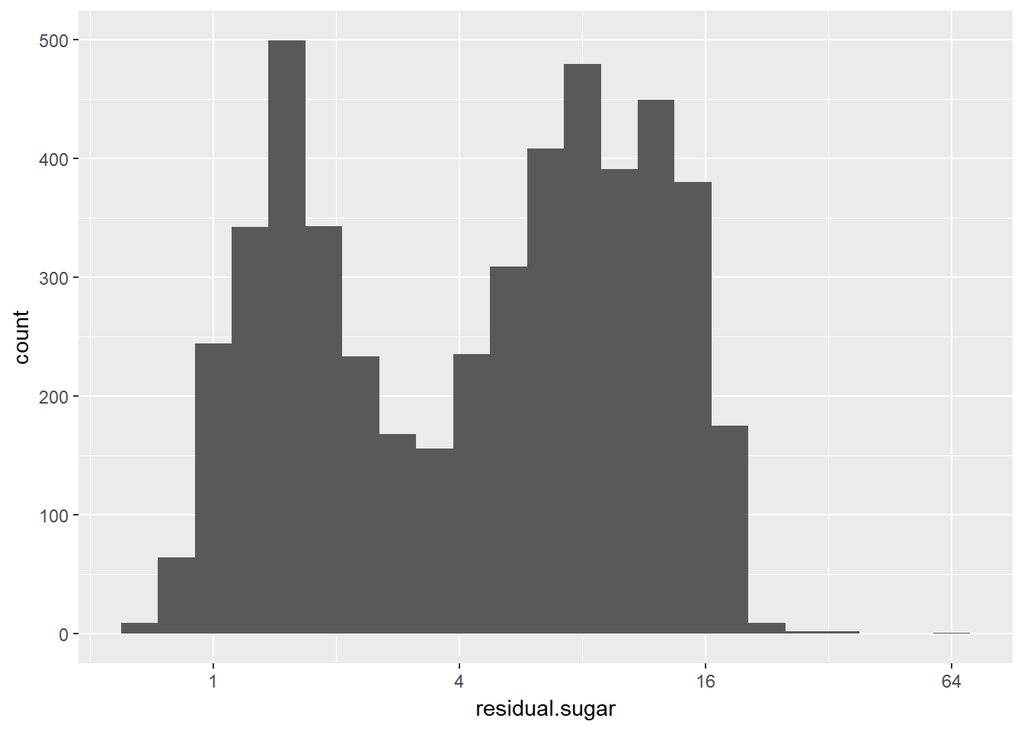

```
##    Min. 1st Qu.  Median    Mean 3rd Qu.    Max.
##   0.600   1.700   5.200   6.391   9.900  65.800
```

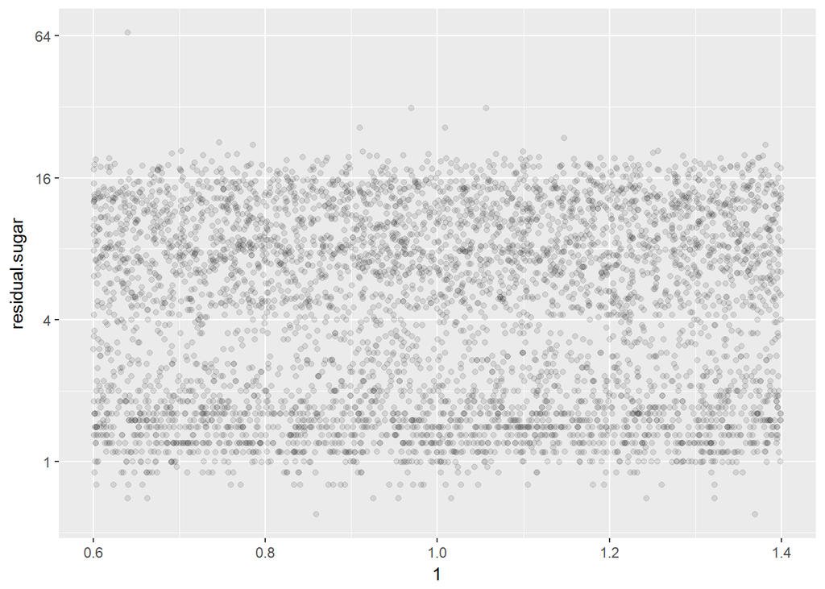

Residual sugar distribution is clearly bimodal. One mode occurs around 1.5 and another around 12

One important thing to note here is that the residual sugar gives us a picture of unfermented sugar left in the wine. The bimodal distribution indicates that there is decent demand for both sweet wines and dry wines. Some may like to have a good taste of wine while some may want to have high alcohol. Here my assumption is that alcohol and sugar content might be realted. I would like to see if their relation.

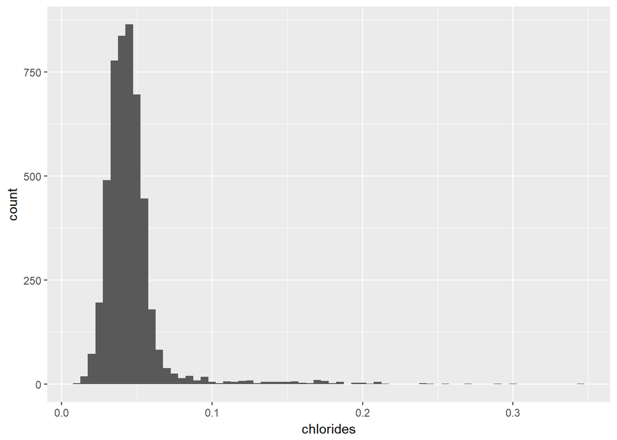

```
##    Min. 1st Qu.  Median    Mean 3rd Qu.    Max.
## 0.00900 0.03600 0.04300 0.04577 0.05000 0.34600
```

Chloride distribution seem to be right skewed with median around 0.043.

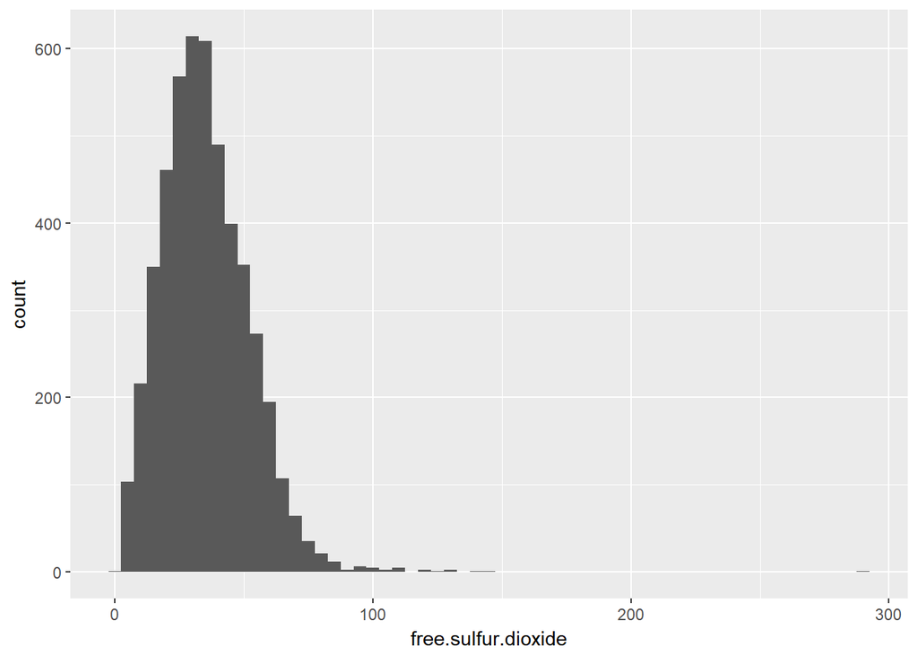

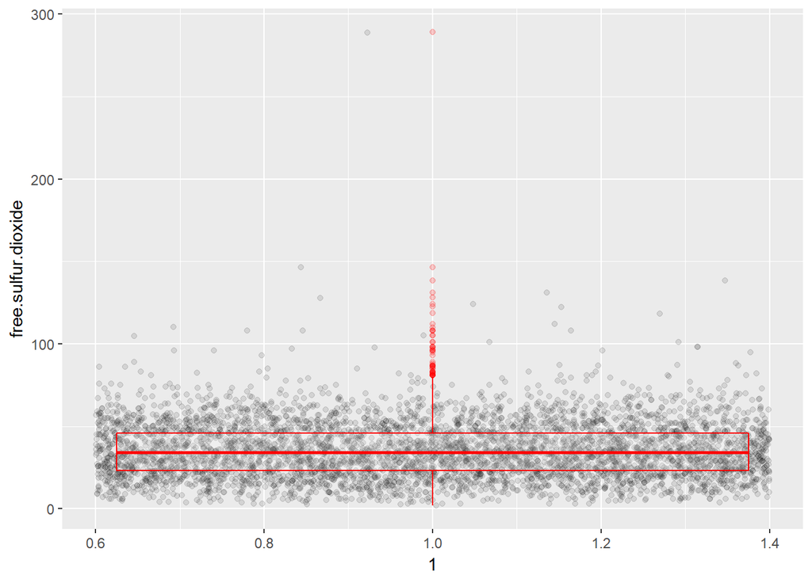

```
##    Min. 1st Qu.  Median    Mean 3rd Qu.    Max.
##    2.00   23.00   34.00   35.31   46.00  289.00
```

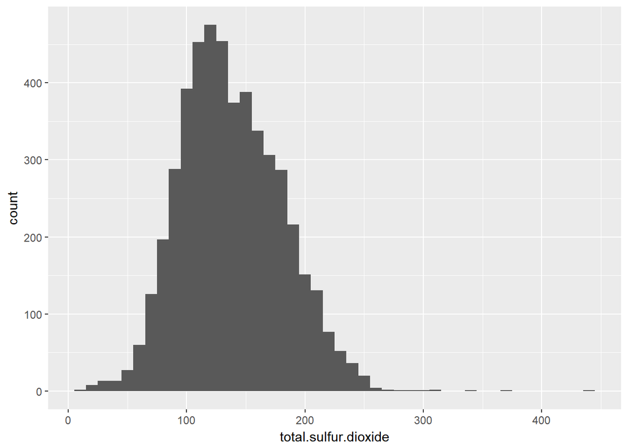

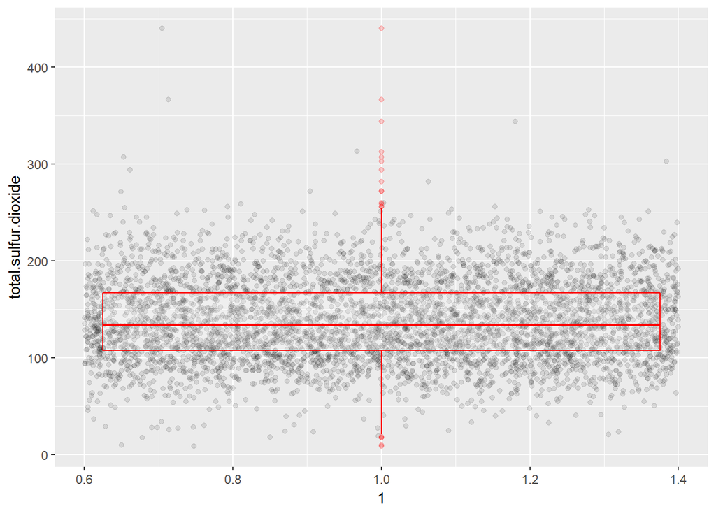

```
##    Min. 1st Qu.  Median    Mean 3rd Qu.    Max.
##     9.0   108.0   134.0   138.4   167.0   440.0
```

Both total & free sulfur dioxide distributions are slight right skewed. There are some outliers as seen from the box plots. Total sulfur dioxide includes free sulfur dioxide as well. Would like to see the relation of bound sulfur dioxide which is the difference between total and free sulfur dioxide and the quality of wines along with the free and total sulfur dioxide.

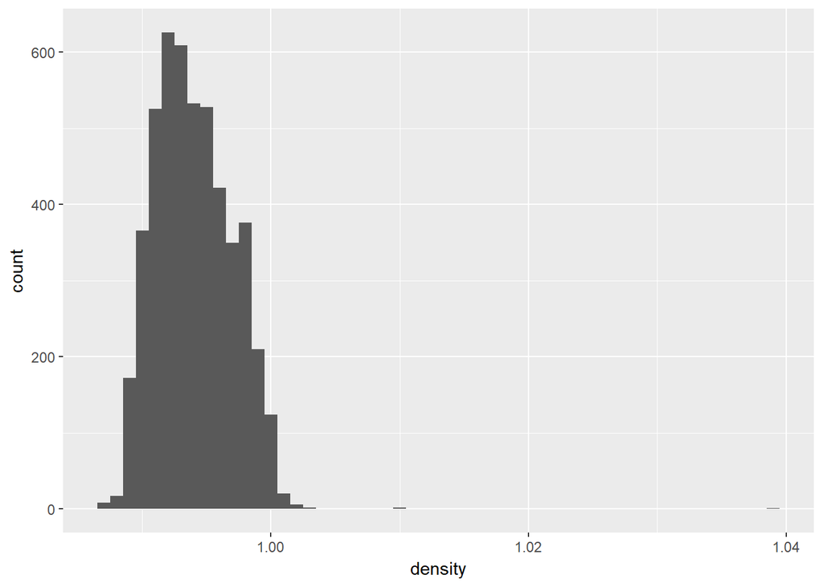

```
##    Min. 1st Qu.  Median    Mean 3rd Qu.    Max.
##  0.9871  0.9917  0.9937  0.9940  0.9961  1.0390
```

Density ranges from 0.9871 (g / cm^3) to 1.039 (g / cm^3). We see that there is not much variation in the density. As we have the different chemical content densities given in the dataset, it is most likely that density is highly correlated with other features. So I want to explore this further in bi-variate analysis.

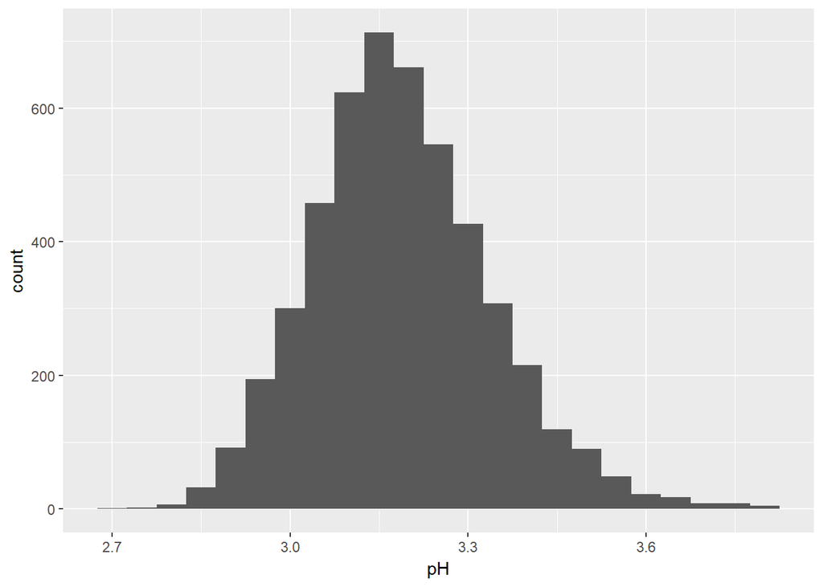

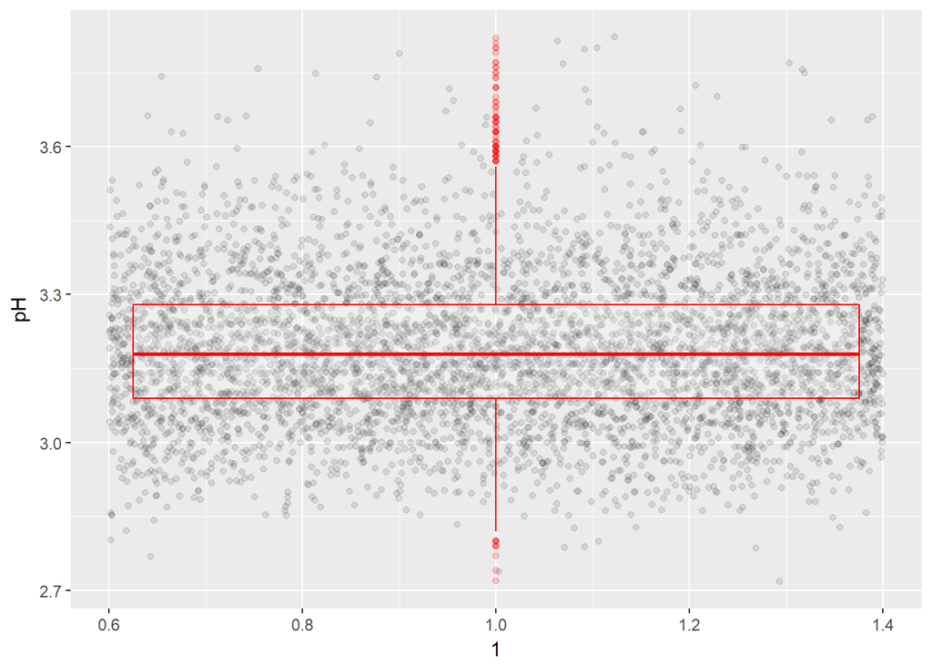

```
##    Min. 1st Qu.  Median    Mean 3rd Qu.    Max.
##   2.720   3.090   3.180   3.188   3.280   3.820
```

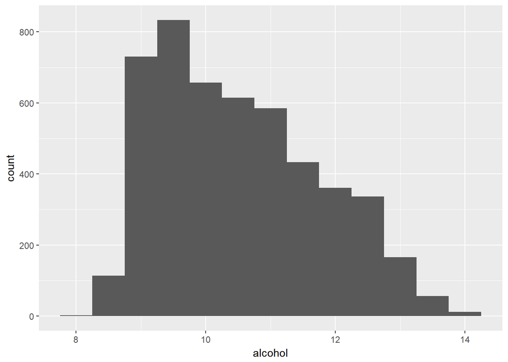

```
##    Min. 1st Qu.  Median    Mean 3rd Qu.    Max.
##    8.00    9.50   10.40   10.51   11.40   14.20
```

The minimum alcohol content is around 8% and maximum is around 14%. The distribution is right skewed with median = 10.4%

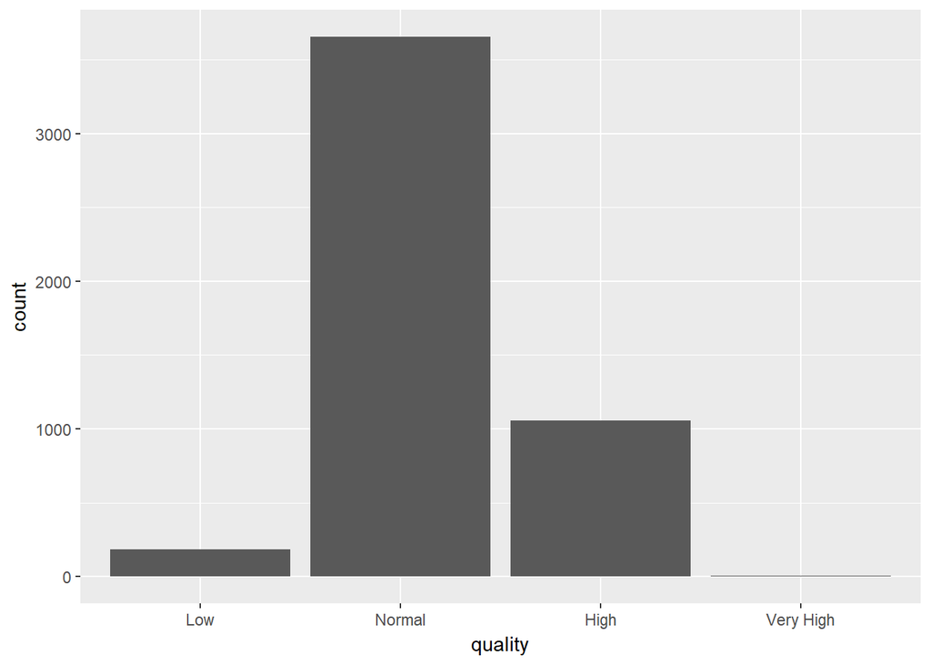

```
##  Very Low       Low    Normal      High Very High
##         0       183      3655      1055         5
```

# Univariate Analysis

### What is the structure of your dataset?

There are 4898 observations with 11 different fields excluding quality field. Every field is a continous variable.

### What is/are the main feature(s) of interest in your dataset?

No judgement has been taken at this stage

### Did you create any new variables from existing variables in the dataset?

1. Bound_sulfur_dioxide which is difference between total sulfur dioxide and the free sulfur dioxide
2. Quality is changed into categorical variable with Very Low (1,2), Low (3,4), Normal (5,6), High (7,8) and Very High (9,10) categories
3. Free sulfur dioxide to Total Sulfur doxide ratio
4. Ratio of alcohol to residual sugar

### Of the features you investigated, were there any unusual distributions?

1. There is a sudden peak in citric acid concentration aroud 0.5 (g / dm^3)
2. Bimodal distribution for residual sugar

# Bivariate Plots Section

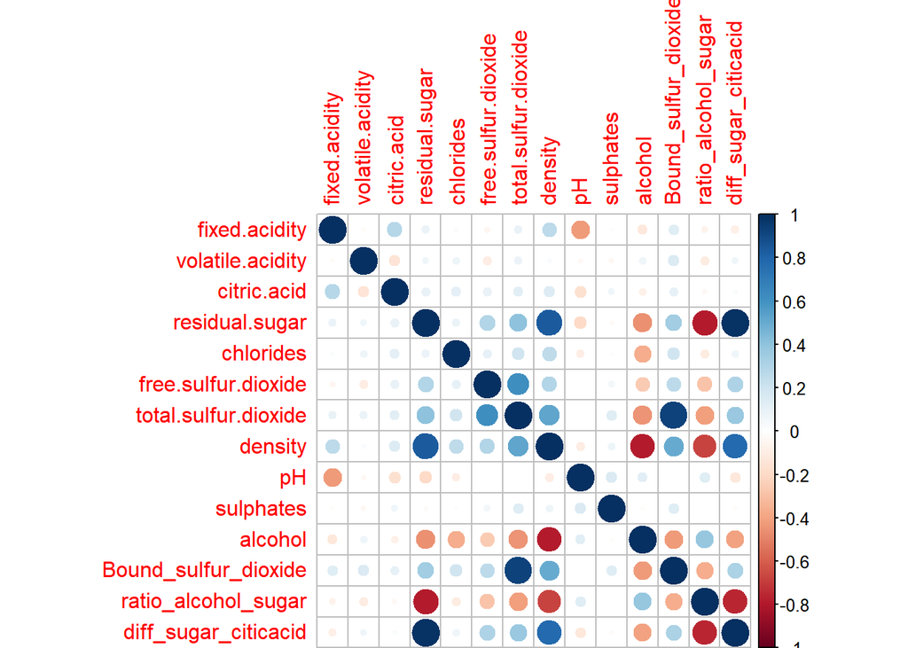

Density is largely correlated (>0.8) to residual.sugar and alcohol percentage(<-0.8) As density is combined concentrations of its contents, this behaviour is expected. Density field can thus be ignored.

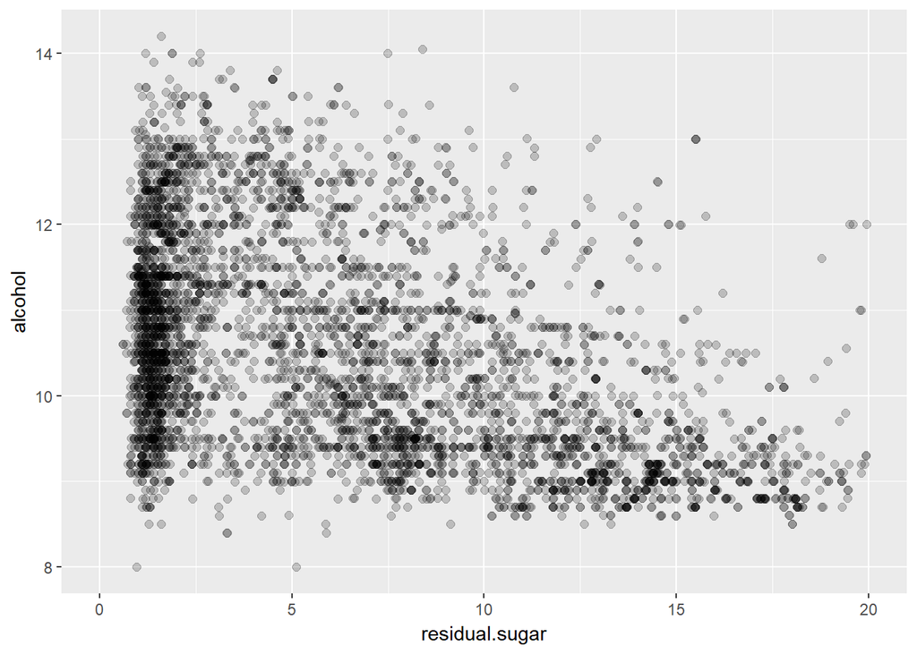

```
##
## Call:
## lm(formula = alcohol ~ residual.sugar, data = subset(data_wine,
##     residual.sugar <= quantile(data_wine$residual.sugar, 0.999)))
##
## Residuals:
##     Min      1Q  Median      3Q     Max
## -3.1331 -0.7959 -0.1587  0.7041  4.1414
##
## Coefficients:
##                 Estimate Std. Error t value Pr(>|t|)
## (Intercept)    11.241716   0.025394  442.69   <2e-16 ***
## residual.sugar -0.114295   0.003148  -36.31   <2e-16 ***
## ---
## Signif. codes:  0 '***' 0.001 '**' 0.01 '*' 0.05 '.' 0.1 ' ' 1
##
## Residual standard error: 1.092 on 4891 degrees of freedom
## Multiple R-squared:  0.2123, Adjusted R-squared:  0.2121
## F-statistic:  1318 on 1 and 4891 DF,  p-value: < 2.2e-16
```

As discuseed earlier, there is expected to be relation between Alcohol percentage and residual sugar content. It was expected that alcohol and residual sugar would have a linear relationship given a fixed amount initial sugar content but looking at the scatter plot and the R2 value of the linear regression, the linear relationship is not apparent.This makes me think that the intial sugar content might not be the same for the wines as it depends on the type of grapes.

The variation of alcohol content decreases with increase in residual sugar content. This is because there should be limit on the intial sugar content present before fermentation.

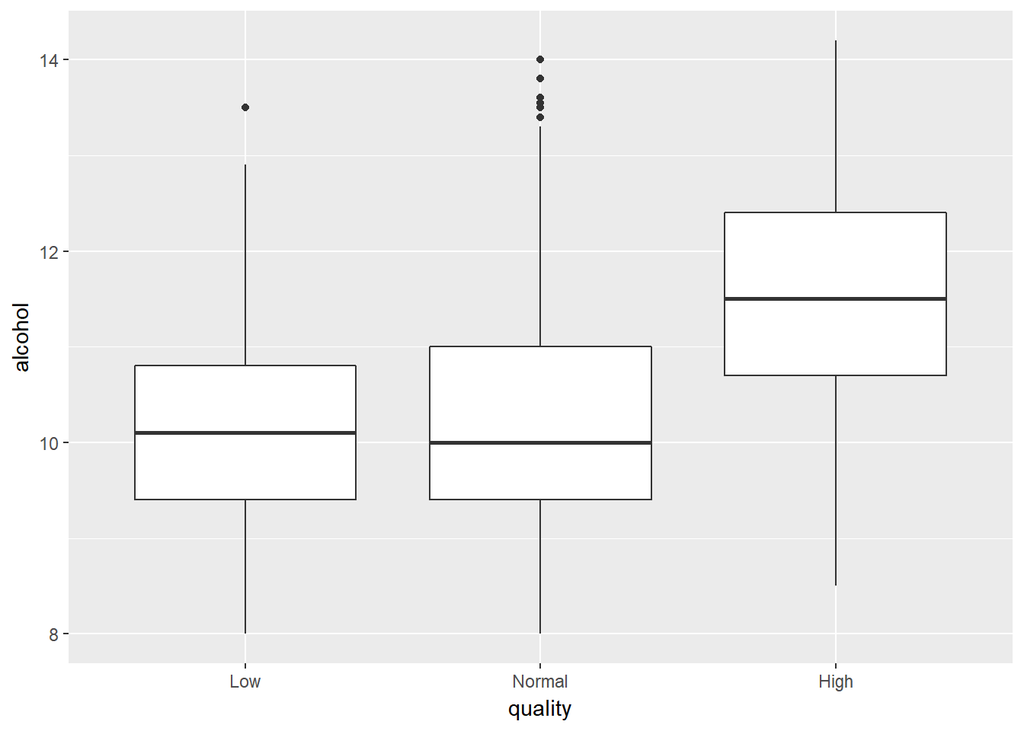

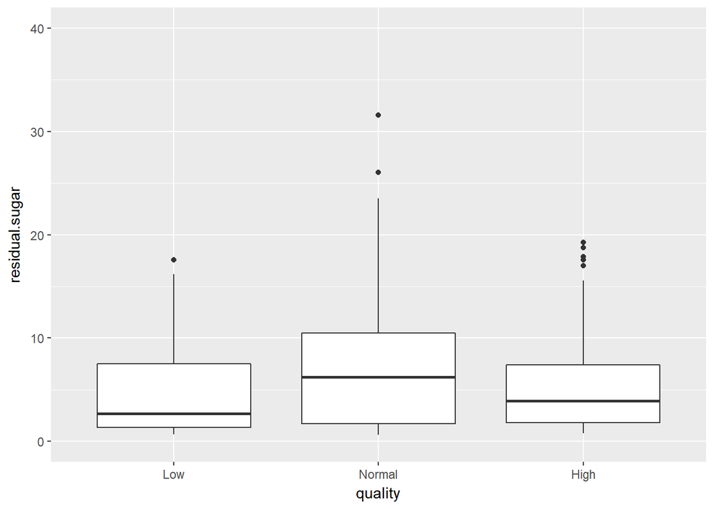

Alcohol concentration seems to be a good indicator of wine quality as there are considerable difference in the medians between Normal and High quality wines

Higher and lower quality wines have lower residual sugar content median compared to that of normal wines.

It is observed that both Very High and Low quality wines can have lower residual sugars. Thus Residual sugar might not be good indicator of quality.It would be interesting to see if residual sugar content combined with citric acid is a good feature for quality.

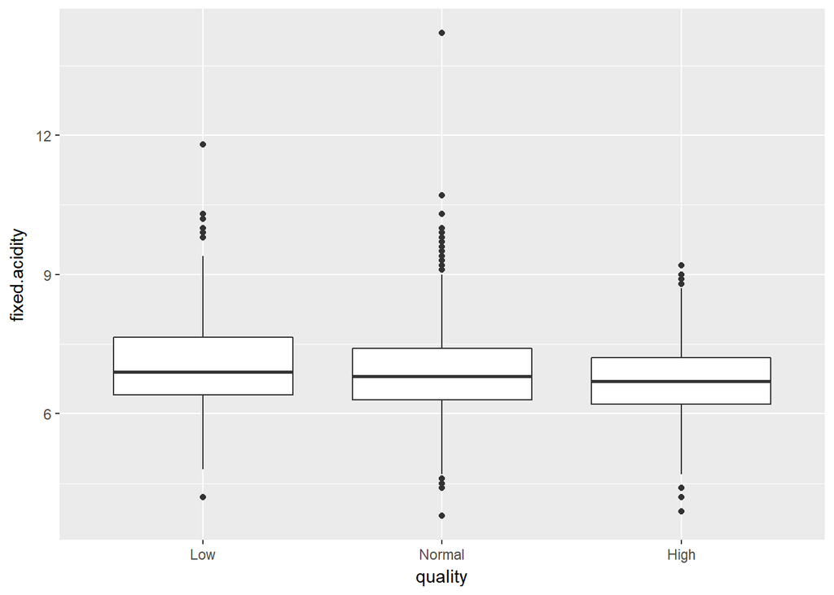

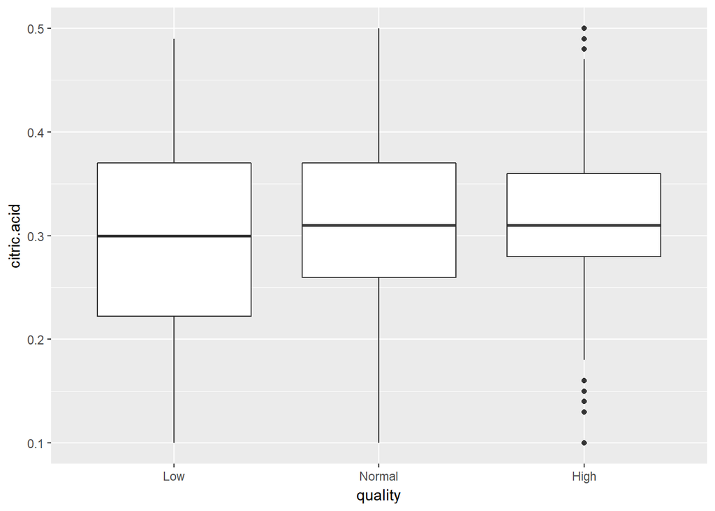

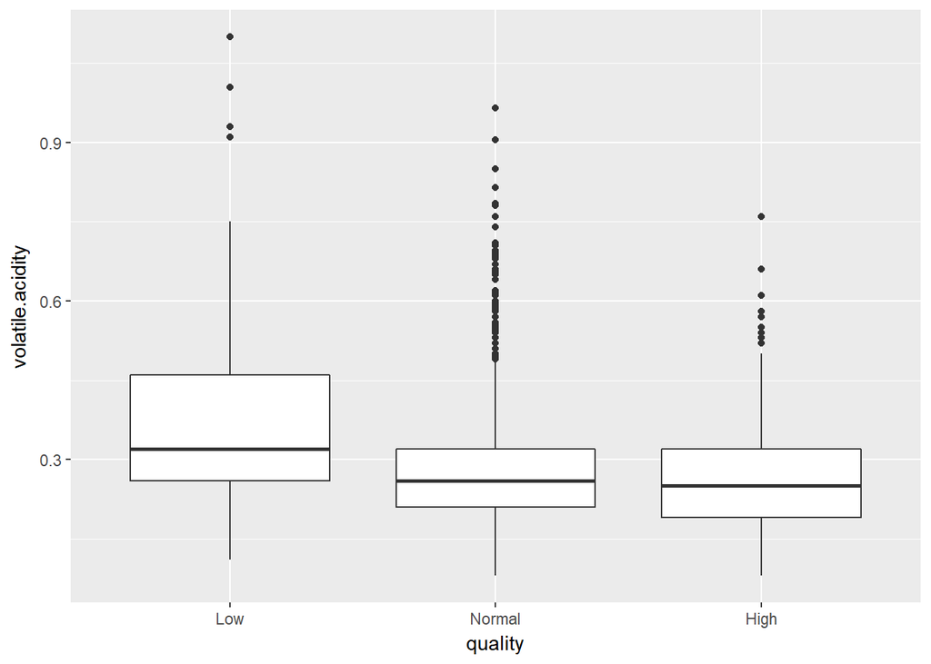

Fixed acidity and Citric acid concentration on the other hand seems to be not much distinguishing the quality of wines.But we can see that the variance of citric acid decreases with increase in quality.

On the other hand volatile acidity seems to be a good feature.

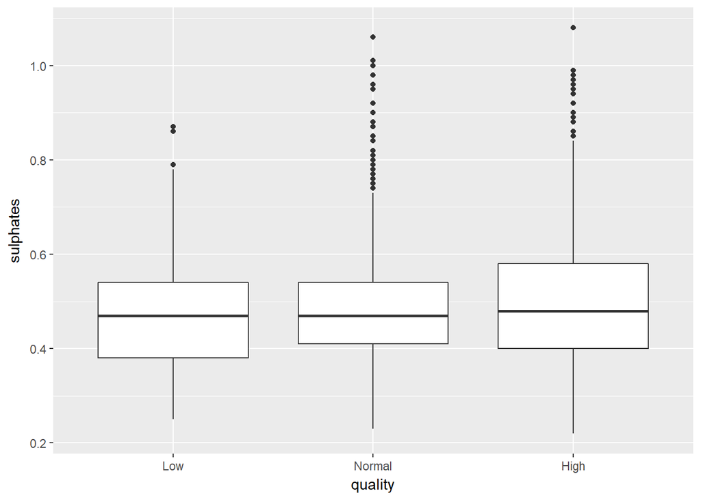

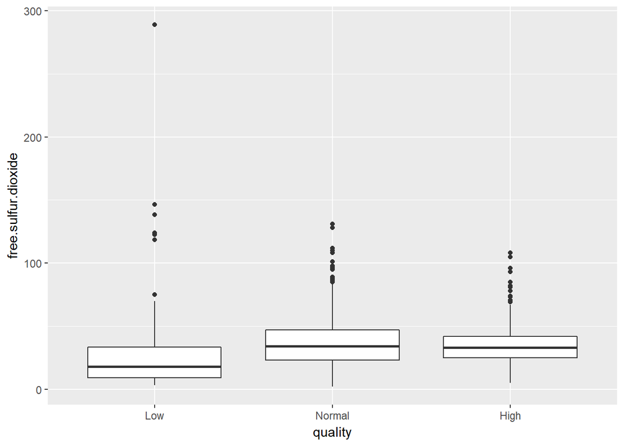

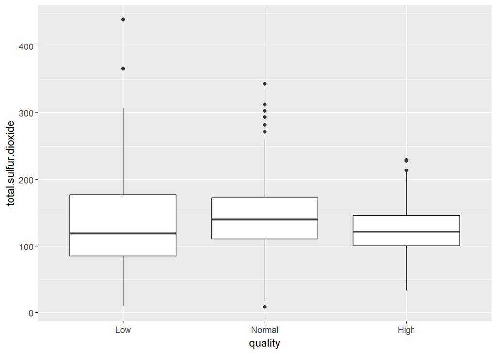

[figure not shown]

Free sulfur dioxide seems to distinguishing among different qualities more than the total sulfur dioxide. We can further analyse to see if the ratio of free to total sulfur dioxide is a better feature for determining quality.

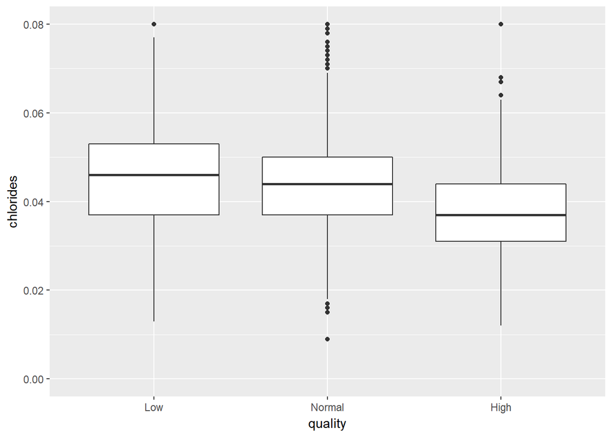

There are lot of outliers in Normal quaity wines in terms of chloride concentation. If we remove some of the outliers, we can see that with the chloride concentration quality decreases. This is expected as the wine starts to taste salty.

# Bivariate Analysis

### Did you observe any interesting relationships between the other features (not the main feature(s) of interest)?

1. Checking the relation between residual sugar and alcohol concentrations. From the scatter plot, it is observed that higher the residual sugar concentration, the narrower the alcohol concentration range becomes. With the process of fermentation, natural sugar present in the grapes is converted to alcohol. Given that there should be a limit on how much initial sugar content grapes can contain, depending on how long the fermentation process goes, more and more sugar is converted into alcohol. So with a lesser residual sugar concentration, it is quite possible to have different levels of alcohol but with higher residual sugar content there is less possibility to have more alcohol content.

2)Density is strongly related to residual sugar and alcohol content. Thus Density can be removed from the list of features as there will be redundant information.

### What was the strongest relationship you found?

Density with residual sugar content and alcohol

# Multivariate Plots Section

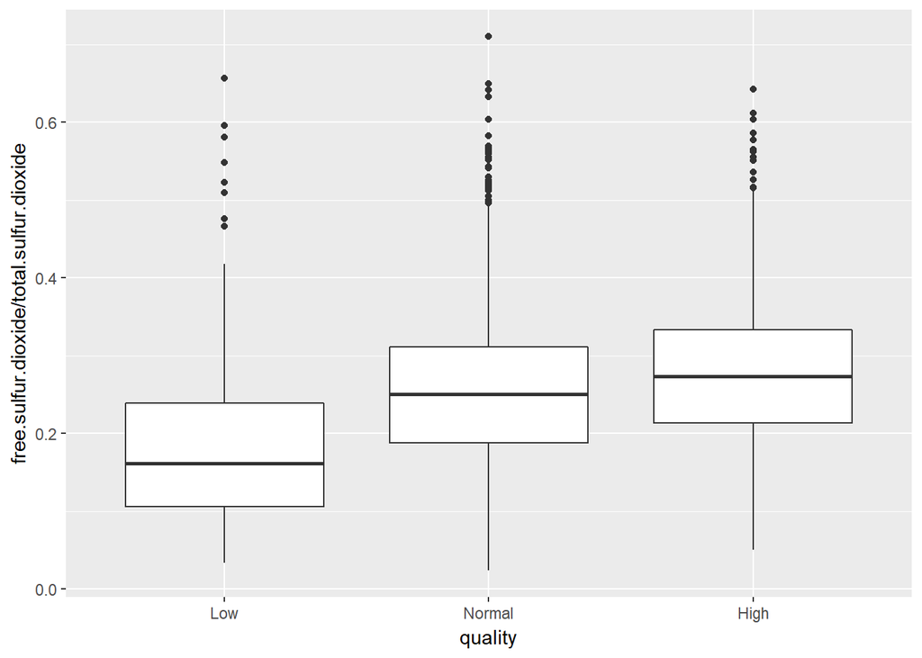

Free to total sulfur dioxide ratio should give us an idea on how much proportion of added sulfur dioxide is actually avaiable for protection against microbes. The trend for quality is as expected and more differentiating than if we take free sulfur dioxide itself.

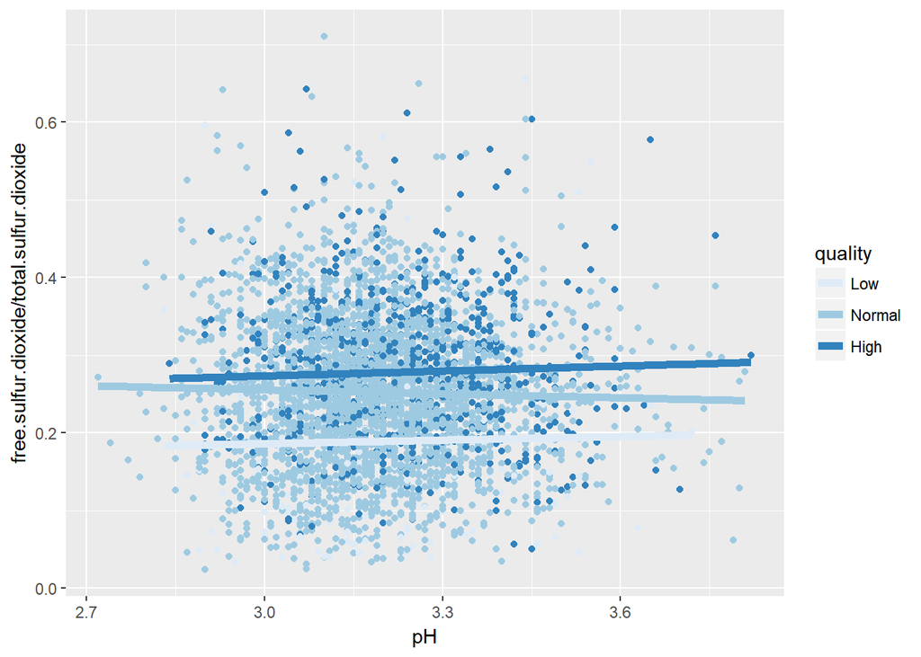

As the amount of free sulfur dioxide for a given total sulfur dioxide may depend on the pH of the solution, it is plotted to check if there is any relation. While there are some trend seen for high quality wins, it is not so prominent.

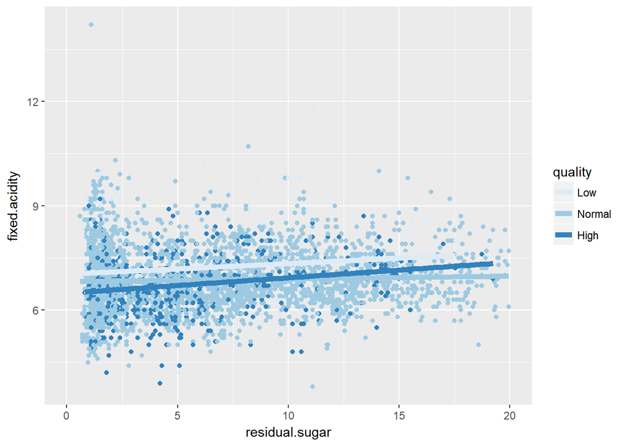

As acidity and sweetness counteract each other, it is interesting to know their relationship.

We see that with increase in fixed acidity, the residual sugar content increases.

# Multivariate Analysis

### Talk about some of the relationships you observed in this part of the investigation. Were there features that strengthened each other in terms of looking at your feature(s) of interest?

1)The ratio of free sulfur dioxide to total sulfur dioxide seems to be good feature that can differentiate well between diffetent qualities of wine.

2)We saw that with increase in fixed acidity, the residual sugar content increases. This shows that grapes are picked at a particular time during the ripening phase as there seems to be an importance to balance out acidity and residual sugar

### Were there any interesting or surprising interactions between features?

No.

# Final Plots and Summary

### Plot One

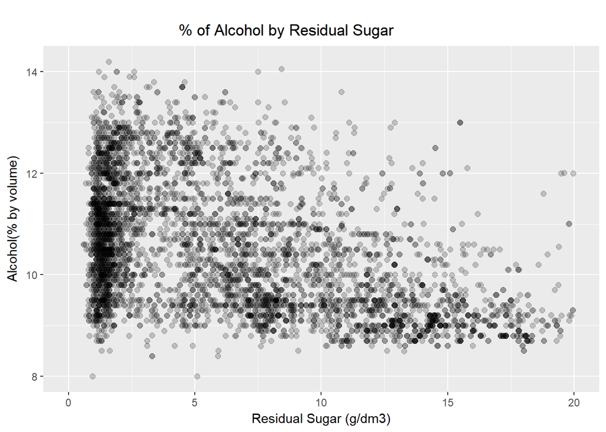

### Description One

It is interesting to notice how variation of alcohol percentage decreases with residual sugar. Even though there is not much linear relationship seen between alcohol and residual sugar, the extent to which alcohol percentage can vary among different wines and the residual sugar content can be related.

### Plot Two

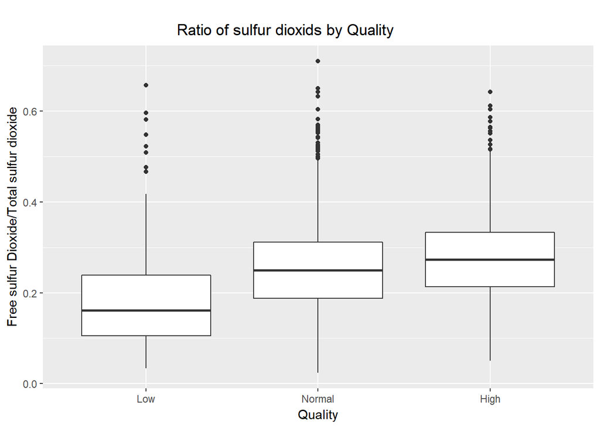

### Description Two

Ratio of sulfur dioxides is a good indicator for Quality of wines as it shows how efficiently the sulfur dioxide is used for protection against microbes

### Plot Three

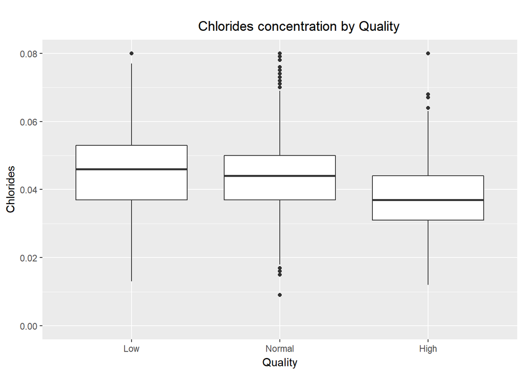

### Description Three

We saw that chlorides concentration is a good feature for identifying wine quality.

# Reflection

While different chemical properties of wines are given, there was no information on the conditions in which the grapes were grown.

There were so many outliers observed in various parts of the analysis and the reasons for such anomalies could not be explained based only on the information given.

More data needs to be collected corresponding to the low and very high quality winesto make the dataset unbiased towards different quality of wines which can then be used for predictive models to predict quality of wine given a set of physio-chemical properties.